# Logistic Regression

## Accuracy

A common method for describing the performance of a classification model is the *confusion matrix*. So, to check how well the model has performed we will construct the confusion matrix, which is a table that is used to show the number of correct and incorrect predictions on a classification problem when the real values of the *test data* are known. For a two class problem it is of the format

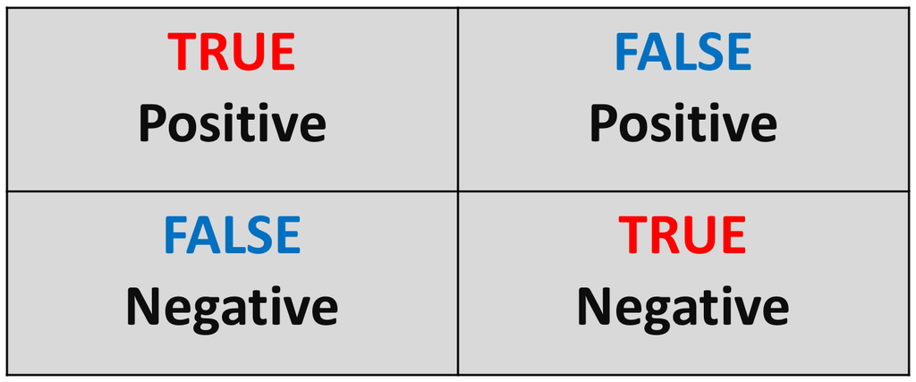

The `TRUE` values are the number of correct predictions made. The values on the diagonal shows the number of correctly classified instances for each category.

```r
> how_well <- data.frame(response_pr, bankrup_test$Y) %>%
+   mutate(result = round(response_pr) == bankrup_test$Y)
>
> how_well
```

|  | response_pr | bankrup_test.Y | result |
| --- | --- | --- | --- |
| 4 | 0.00 | 0 | TRUE |
| 20 | 0.00 | 0 | TRUE |
| 22 | 0.01 | 0 | TRUE |
| 24 | 0.00 | 0 | TRUE |
| 30 | 0.00 | 0 | TRUE |
| 38 | 1.00 | 1 | TRUE |
| 40 | 1.00 | 1 | TRUE |
| 44 | 1.00 | 1 | TRUE |
| 46 | 0.93 | 1 | TRUE |
| 47 | 1.00 | 1 | TRUE |

[output cut: 3 more lines]

```r
> confusion_matrix <- table(bankrup_test$Y, round(response_pr))
> confusion_matrix
```

```
##
##     0 1
##   0 5 0
##   1 0 8
```

The simplest metric for model classification is the overall *accuracy rate*. To evaluate predicted classes, we are going to create a function that can calculate the accuracy of the fitted model.

```r
> # calculate percentage accuracy
> accuracy <- function(x){
+   sum(diag(x) / (sum(rowSums(x)))) * 100
+ }
```

Knowing how the probabilities are estimated for the test data we can now describe the performance of a classification model using the confusion matrix.

```r
> accuracy(confusion_matrix)
```

```
## [1] 100
```

Although the overall accuracy rate might be easy to compute and to interpret, it makes no distinction about the type of errors being made.

## **YOUR TURN** 👇

Practise by doing the following exercises:

Access the `stroke` data set from https://tanjakec.github.io/mydata/stroke.csv. The data dictionary of this data set is given in https://tanjakec.github.io/mydata/Stroke_DataDictionary.docx word document.

1. Split the data into a training and a test set. Fit a logistic regression model using the training part of the data set.
2. Predict the response for the test set.
3. What is the value of the performance metric?

[Creative Commons Attribution-ShareAlike 4.0 International License.](https://creativecommons.org/licenses/by-sa/4.0/)